# Challenge 5: Visualizaing Time and Space

Author

Vara Prasad Gudi

Published

November 6, 2024

**Make sure you change the author’s name and add the data in the above YAML header.**

## Setup

If you have not installed the following packages, please install them before loading them.

```r
# for data wrangling
library(dplyr)
library(tidyr)
library(lubridate)
library(readr)

#for plotting over time
library(ggplot2)


# for plotting over space
library(sp)
library(sf)
library(maps)
```

## Challenge Overview

In this challenge, we will practice the visualization skills learned in the class with two datasets to capture the temporal and spatial patterns.

There will be coding components and writing components. Please read the instructions for each part and complete the associated tasks and questions.

## Datasets

- Part 1. The UFO Sightings Data (50%)
- Part 2. The Hospital Location Data (50%)

Download the files from Canvas, save them in the proper place in your DACSSS 601 folder, and then read the datasets using the correct R commands.

## Part 1. The UFO Sightings Data (5 pts)

This data contains over 80,000 reports of UFO sightings over the last century in six major countries (and other places). You can learn more about this data by checking: https://www.kaggle.com/datasets/NUFORC/ufo-sightings.

1. **Read and Describe the Data (0.5 pts)**

   ```r
   ufo_data <- read_csv('./data/complete_UFO.csv', show_col_types = FALSE)
   ```

   ```r
   problems(ufo_data)
   ```

   | row | col | expected | actual | file |
   | --- | --- | --- | --- | --- |
   | 18088 | 6 | a double | 2` | E:/CICS/4-Fall24/601/DACSS 601 R project/Challenge 5/data/complete_UFO.csv |
   | 38131 | 6 | a double | 8` | E:/CICS/4-Fall24/601/DACSS 601 R project/Challenge 5/data/complete_UFO.csv |
   | 43669 | 6 | a double | 0.5` | E:/CICS/4-Fall24/601/DACSS 601 R project/Challenge 5/data/complete_UFO.csv |

   ```r
   ufo_data <- ufo_data %>% mutate(`duration (seconds)` = as.numeric(gsub("`", "", `duration (seconds)`)))
   ```

   ```r
   head(ufo_data)
   ```

   | datetime | city | state | country | shape | duration (seconds) | duration (hours/min) | comments | date posted | latitude | longitude | ...12 |
   | --- | --- | --- | --- | --- | --- | --- | --- | --- | --- | --- | --- |
   | 11/11/1906 | wien (austria) | NA | NA | other | 10800 | 3 h | The oldest professional photo of a UFO object is from Wien observatory&#44 in 1906&#33 | 12/23/2002 | 48.208174 | 16.373819 | NA |
   | 1/2/1910 | kirksville (near) | mo | us | disk | 120 | minutes | Historical sighting (1903 - 1913) Northern Missouri | 9/15/2005 | 40.1947222 | -92.583056 | NA |
   | 5/28/1910 | solon | me | us | unknown | 0 | don&#39t know | entry in my great-grandmother&#39s diary&#44date 28 may 1910&#44refers to watching the comet zig-zaging in the sky&#44 followed by a zig-zag diagra | 12/5/2001 | 44.9494444 | -69.858889 | NA |
   | 6/1/1910 | wills point | tx | us | cigar | 120 | 2 minutes | Cigar shaped object moving from West to East | 4/16/2005 | 32.7091667 | -96.008056 | NA |
   | 9/15/1914 | meeting lake (canada) | ab | NA | unknown | 0 | NA | Night flying &quot;airplane&quot; with search lights observed on several occasions near Meeting Lake&#44 Alberta in late 1914. | 2/1/2007 | 55.170828 | -118.837956 | NA |
   | 4/5/1916 | france (above; from aircraft) | NA | NA | cigar | 60 | about 1 min. | ((NUFORC Note: Possible hoax. PD)) Saw 3 cigar shaped crafts. | 3/9/2004 | 46.227638 | 2.213749 | NA |

   **What are the dimensions of the data?**
   - Rows: 88875, Columns: 12

   ```r
   dim(ufo_data)
   ```

   ```
   [1] 88875    12
   ```

   **What do the columns mean?**
   - Columns
     - datetime - Time of UFO sighting
     - city - City of sighting
     - state - State of sighting
     - country - Country where UFO is sighted
     - shape - Shape of the sighted UFO
     - duration(seconds) - how many seconds a UFO has been seen
     - duration(hours/min) - Sighting duration in hours/minutes
     - comments - Description of sighting
     - date_posted - Date sighting was reported
     - latitude and longitude - Geo location of the UFO sighting
     - …12 - an indicator variable, 0 if lat/long missing

   **What is the unit of observation?**
   - UFO Sighting information
2. Please plot a temporal/time-series graph to present the following patterns. **You may need to subset or mutate the data for graphing.**

   (1) the total number of UFO sighting reports over the years. **(1.5 pts)**

   ```r
   ufo_modf <- ufo_data

   ufo_modf$datetime <- mdy(ufo_modf$datetime)

   ufo_modf$year <- year(ufo_modf$datetime)

   head(select(ufo_modf,datetime,year))
   ```

   | datetime | year |
   | --- | --- |
   | 1906-11-11 | 1906 |
   | 1910-01-02 | 1910 |
   | 1910-05-28 | 1910 |
   | 1910-06-01 | 1910 |
   | 1914-09-15 | 1914 |
   | 1916-04-05 | 1916 |

   ```r
   ufo_by_yr <- ufo_modf |> filter(!is.na(year)) |> group_by(year) |> summarise(count = n())

   head(ufo_by_yr)
   ```

   | year | count |
   | --- | --- |
   | 1906 | 1 |
   | 1910 | 3 |
   | 1914 | 1 |
   | 1916 | 1 |
   | 1917 | 1 |
   | 1920 | 2 |

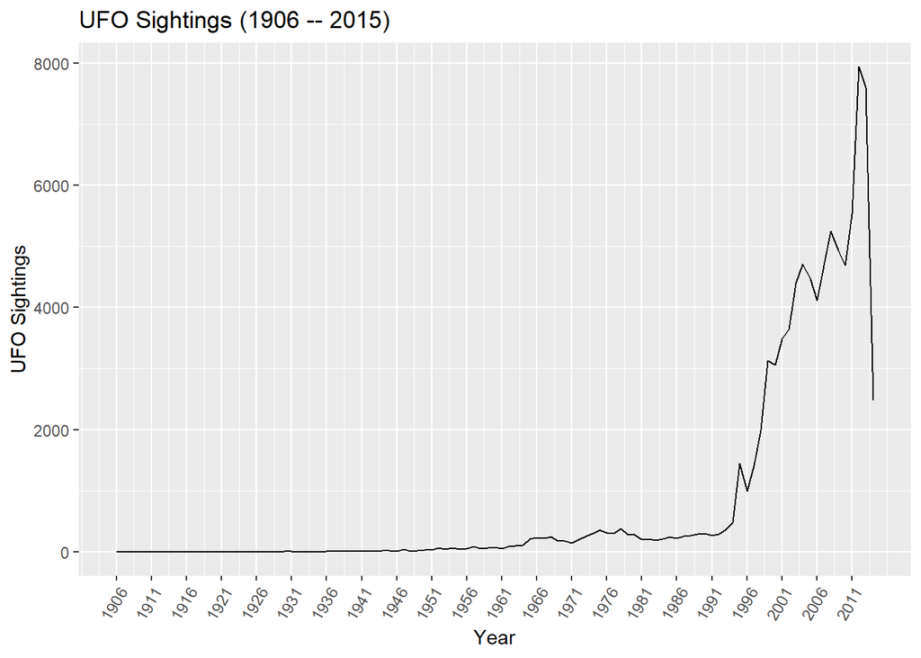

   ```r
   ggplot(ufo_by_yr, aes(x = as.Date(year), y = count))+
     geom_line()+
     scale_x_continuous(breaks = seq(1906, 2015, by = 5)) +
     theme(axis.text.x=element_text(angle=60, hjust=1)) +
     labs(title = "UFO Sightings (1906 -- 2015)", x="Year", y = "UFO Sightings")
   ```

   (2) the total number of UFO sighting reports by months between 2 010-01-01 and 2014-01-01. **(1.5 pts)**

   ```r
   # add year,month,year-month column in the data
   ufo_modf <- ufo_modf |>
     mutate(month = format(datetime, "%m"), year = format(datetime, "%Y"), `year-month`=format(datetime, "%Y-%m"))

   head(select(ufo_modf, datetime, year, month, `year-month`))
   ```

   | datetime | year | month | year-month |
   | --- | --- | --- | --- |
   | 1906-11-11 | 1906 | 11 | 1906-11 |
   | 1910-01-02 | 1910 | 01 | 1910-01 |
   | 1910-05-28 | 1910 | 05 | 1910-05 |
   | 1910-06-01 | 1910 | 06 | 1910-06 |
   | 1914-09-15 | 1914 | 09 | 1914-09 |
   | 1916-04-05 | 1916 | 04 | 1916-04 |

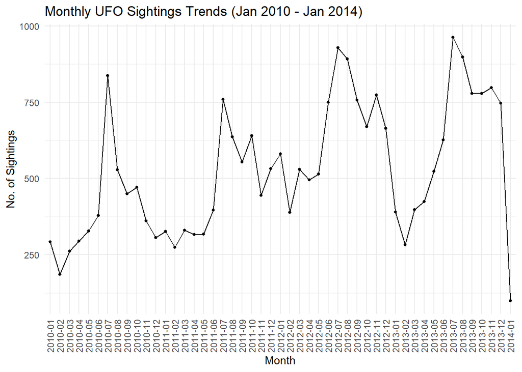

   ```r
   # filter based on date first
   ufo_modf <- ufo_modf |>
     filter(datetime >= as.Date("2010-01-01") & datetime <= as.Date("2014-01-01"))

   # Count sightings by month and year
   ufo_month_year <- count(ufo_modf, `year-month`, name = "UFO Sightings")

   # Plotting
   ggplot(ufo_month_year, aes(x=`year-month`, y=`UFO Sightings`,group=1)) +
     geom_point(size=1) +
     geom_line() +
     labs(title="Monthly UFO Sightings Trends (Jan 2010 - Jan 2014)", x="Month", y="No. of Sightings") +
     theme_minimal() +
     theme(axis.text.x = element_text(angle = 90, vjust = 0.5, hjust=1))
   ```

5. **(Optional)** Suppose we are interested in describing the country variations in types and numbers of UFO sighting reports. How can we use bar plots to visualize the difference across countries (using the `country` column, you can recode the empty cells with `"others"`)? Is this an effective visualization? Why or why not? **Note that you may need to do data transformation or mutation in order to make the graph.** **(0 pts)**

   ```r
   # type your code here.
   ```

## Part 2. The Hospital Location Data (5 pts)

This data contains the locations of hospitals in the United States. You can learn more about this data by checking: https://www.kaggle.com/datasets/andrewmvd/us-hospital-locations

1. **Read and Describe the Data (0.5 pts)**

   ```r
   US_hosp_info <- read_csv('./data/us_hospital_locations.csv', show_col_types = FALSE)

   head(US_hosp_info)
   ```

   | ID | NAME | ADDRESS | CITY | STATE | ZIP | TYPE | STATUS | POPULATION | COUNTY | COUNTRY | LATITUDE | LONGITUDE | OWNER | BEDS |
   | --- | --- | --- | --- | --- | --- | --- | --- | --- | --- | --- | --- | --- | --- | --- |
   | 5793230 | CENTRAL VALLEY GENERAL HOSPITAL | 1025 NORTH DOUTY STREET | HANFORD | CA | 93230 | GENERAL ACUTE CARE | CLOSED | 49 | KINGS | USA | 36.33616 | -119.6457 | PROPRIETARY | 49 |
   | 53391362 | LOS ROBLES HOSPITAL & MEDICAL CENTER - EAST CAMPUS | 150 VIA MERIDA | WESTLAKE VILAGE | CA | 91362 | GENERAL ACUTE CARE | OPEN | 62 | VENTURA | USA | 34.15494 | -118.8157 | PROPRIETARY | 62 |
   | 11190023 | EAST LOS ANGELES DOCTORS HOSPITAL | 4060 WHITTIER BOULEVARD | LOS ANGELES | CA | 90023 | GENERAL ACUTE CARE | OPEN | 127 | LOS ANGELES | USA | 34.02365 | -118.1842 | PROPRIETARY | 127 |
   | 17090028 | SOUTHERN CALIFORNIA HOSPITAL AT HOLLYWOOD | 6245 DE LONGPRE AVENUE | HOLLYWOOD | CA | 90028 | GENERAL ACUTE CARE | OPEN | 100 | LOS ANGELES | USA | 34.09639 | -118.3252 | PROPRIETARY | 100 |
   | 23691706 | KINDRED HOSPITAL BALDWIN PARK | 14148 FRANCISQUITO AVENUE | BALDWIN PARK | CA | 91706 | GENERAL ACUTE CARE | OPEN | 95 | LOS ANGELES | USA | 34.06304 | -117.9674 | PROPRIETARY | 95 |
   | 25190712 | LAKEWOOD REGIONAL MEDICAL CENTER | 3700 EAST SOUTH STREET | LAKEWOOD | CA | 90712 | GENERAL ACUTE CARE | OPEN | 172 | LOS ANGELES | USA | 33.85971 | -118.1484 | PROPRIETARY | 172 |

   **What are the dimensions of the data?**
   - Rows: 7596, Columns: 15

   ```r
   dim(US_hosp_info)
   ```

   ```
   [1] 7596   15
   ```

   What do the columns mean?
   - Columns:
     - ID - Unique identifier for each hospital
     - NAME - Hospital name
     - ADDRESS - Street address of the hospital
     - CITY - City where the hospital is located
     - STATE - State where the hospital is located
     - ZIP - ZIP code of the hospital’s location
     - TYPE - Hospital type (e.g., General Acute Care, Psychiatric, Children, Long Term Care, Critical Access, Rehabilitation, Military, Women, Special, Chronic Disease)
     - STATUS - Operational status of the hospital (Open or Closed)
     - POPULATION - Patient population in the hospital
     - COUNTY - County where the hospital is located
     - COUNTRY - Country where the hospital is located
     - LATITUDE and LONGITUDE - Geo Location of the hospital
     - OWNER - Ownership type (e.g., Proprietary, Local Government, District/Authority Government, Non-Profit, State Government, Federal Government, Limited Liability Company)
     - BEDS - Number of beds available in the hospital

       **What is the unit of observation?**  
       It is US Hospital’s information
2. Download the `cb_2018_us_state_500k.shp` data from https://www2.census.gov/geo/tiger/GENZ2018/shp/cb_2018_us_state_500k.zip). Put the whole `cb_2018_us_state_500k` folder in your data folder. Plot a USA map with states boundaries using `geom_sf()`. **(1.5 pts)**

   ```r
   states_geom <- st_read("./data/cb_2018_us_state_500k/cb_2018_us_state_500k.shp")
   ```

   ```r
   head(states_geom)
   ```

   |  | STATEFP | STATENS | AFFGEOID | GEOID | STUSPS | NAME | LSAD | ALAND | AWATER | geometry |
   | --- | --- | --- | --- | --- | --- | --- | --- | --- | --- | --- |
   | 1 | 28 | 01779790 | 0400000US28 | 28 | MS | Mississippi | 00 | 121533519481 | 3926919758 |  |
   | 2 | 37 | 01027616 | 0400000US37 | 37 | NC | North Carolina | 00 | 125923656064 | 13466071395 |  |
   | 3 | 40 | 01102857 | 0400000US40 | 40 | OK | Oklahoma | 00 | 177662925723 | 3374587997 |  |
   | 4 | 51 | 01779803 | 0400000US51 | 51 | VA | Virginia | 00 | 102257717110 | 8528531774 |  |
   | 5 | 54 | 01779805 | 0400000US54 | 54 | WV | West Virginia | 00 | 62266474513 | 489028543 |  |
   | 6 | 22 | 01629543 | 0400000US22 | 22 | LA | Louisiana | 00 | 111897594374 | 23753621895 |  |

   ```r
   dim(states_geom)
   ```

   ```
   [1] 56 10
   ```

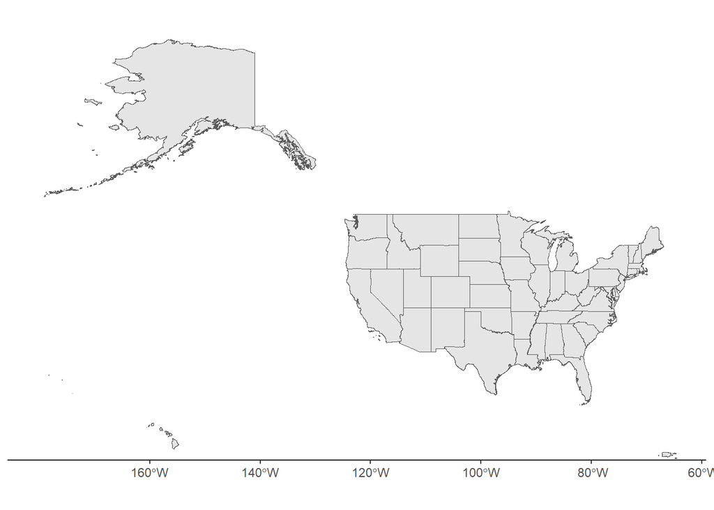

   ```r
   # USA Map with state boundaries
   USA_Map <- ggplot() +
     geom_sf(data = states_geom) +
     coord_sf(xlim = c(-180, -65), ylim = c(20, 70)) +
     theme_classic()

   USA_Map
   ```

3. Plot the hospital locations using the *LONGITUDE* and *LATITUDE* with `geom_point()` on the USA map generated above. Mark OPEN and CLOSED hospitals using different colors. **(1.5 pts)**

   ```r
   hospitals_in_USA <- USA_Map +
     geom_point(data = US_hosp_info, aes(x = LONGITUDE, y = LATITUDE, color = STATUS), size = 0.2) +
     scale_color_manual(values = c("OPEN" = "green", "CLOSED" = "red")) +
     labs(title = "Hospital Locations by Operational Status (Open/Closed)", x = "Longitude", y = "Latitude")
   ```

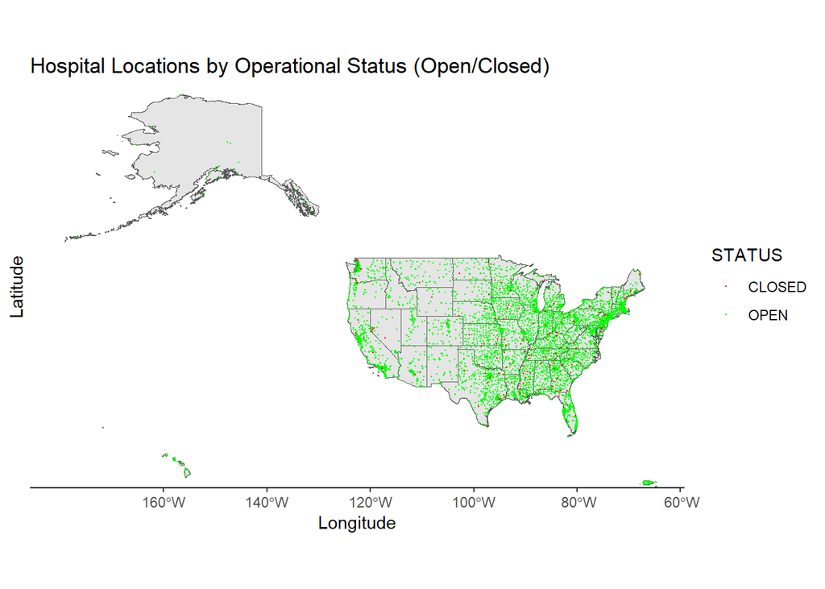

   ```r
   print(hospitals_in_USA)
   ```

4. **Please write a paragraph describing the pattern of the hospital locations you find on the map above.** **(1.5 pts)**  
   The map above shows that most hospitals in the dataset are open (marked in green), with only a small number marked as closed. Hospital locations are concentrated primarily in the eastern and mid-eastern regions, with a secondary concentration along the West Coast. The eastern region has a notably high density of hospitals compared to the less dense distribution in the western region. Alaska has very few hospitals, while Hawaii, though also having a limited number, shows a higher density of hospitals within its area.